# Tarea_III

[figure not shown]

## Tarea N°3: ¿Qué factor "explica" la muerte de COVID por comuna del Gran Santiago?

### Alumno: Claudio Ballerini

### Profesor: Leonardo Ferres

### Fecha: 12/07/2021

Se sabe poco sobre los factores socio-economicos que influyen en el número de muertes por COVID en Chile.

Ahora, su tarea es construir un modelo de regresión en Python para predecir "muertes por covid" teniendo en cuenta el HDI de la comuna, y el número de vacunas administradas. Es decir, su modelo solo tiene que tomar datos desde después del 24 de diciembre de 2020, que es cuando empezamos a administrar vacunas.

Evaluación:

1. Encontrar los datos (10%)
2. Pre-proceso y limpieza de datos (30%)
3. Tratamiento de "muertes por semana" (20%)
4. Gráfico (10%)
5. Explicar el modelo (20%)
6. Subir el notebook a github (10%)

Tienen que mandarme, como resultado, el link al github repo con las tareas. Yo voy a abrir el notebook que se llame: "tarea3.ipynb"

Ps. https://www.statsmodels.org/stable/regression.html

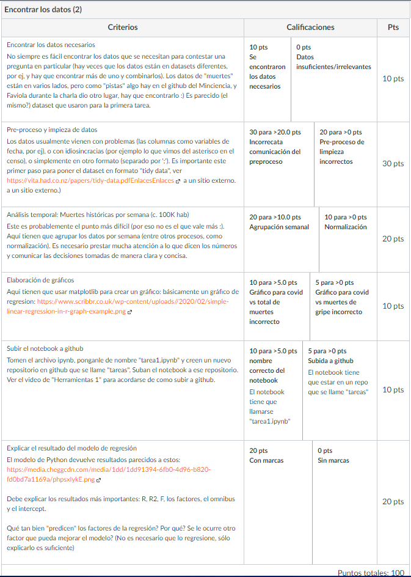

#### Importación de Librerías

```python
import pandas as pd
import numpy as np
import matplotlib.pyplot as plt
from matplotlib.pyplot import figure
import seaborn as sns

from scipy.stats import pearsonr
from sklearn.linear_model import LinearRegression
from sklearn.model_selection import train_test_split
from sklearn.metrics import r2_score
from sklearn.metrics import mean_squared_error
import statsmodels.api as sm
import statsmodels.formula.api as sm
```

#### Se prepara el dataframe de riqueza utilizado en la tarea anterior

```python
Riqueza = pd.read_csv("Riqueza_Comuna.csv", sep = ",", header = 0)
```

```python
Riqueza.head()
```

|  | comuna | LEI | II | EI | idh | HDI |
| --- | --- | --- | --- | --- | --- | --- |
| 0 | 13101 | 0.791672 | 0.873137 | 0.924099 | 0.807 | 0.861222 |
| 1 | 13102 | 0.782817 | 0.800343 | 0.713499 | 0.743 | 0.764616 |
| 2 | 13103 | 0.752447 | 0.750382 | 0.657961 | 0.683 | 0.718874 |
| 3 | 13104 | 0.784872 | 0.760697 | 0.705426 | 0.707 | 0.749584 |
| 4 | 13105 | 0.777236 | 0.780019 | 0.673876 | 0.711 | 0.742015 |

```python
#Riqueza = Riqueza_SinLimpiar.dropna(axis = 0)
```

```python
#Riqueza
```

#### Por otro lado, se utiliza el dataframe "DEFUNCIONES_FUENTE_DEIS_2016_2021_01072021.csv", proveniente del departamento de Estadísticas e Información de Salud, de Ministerio de Salud, Gobierno de Chile (http://deis.minsal.cl/wp-content/uploads/2021/07/DEFUNCIONES_FUENTE_DEIS_2016_2021_01072021.zip)

```python
Defunciones = pd.read_csv('DEFUNCIONES_FUENTE_DEIS_2016_2021_01072021.csv', sep = ';', encoding = 'latin-1')
```

```python
Defunciones.columns = ['ANO_DEF','FECHA_DEF','GLOSA_SEXO','EDAD_TIPO','EDAD_CANT','CODIGO_COMUNA_RESIDENCIA','GLOSA_COMUNA_RESIDENCIA','GLOSA_REG_RES','DIAG1','CAPITULO_DIAG1','GLOSA_CAPITULO_DIAG1','CODIGO_GRUPO_DIAG1','GLOSA_GRUPO_DIAG1','CODIGO_CATEGORIA_DIAG1','GLOSA_CATEGORIA_DIAG1','CODIGO_SUBCATEGORIA_DIAG1','GLOSA_SUBCATEGORIA_DIAG1','DIAG2','CAPITULO_DIAG2','GLOSA_CAPITULO_DIAG2','CODIGO_GRUPO_DIAG2','GLOSA_GRUPO_DIAG2','CODIGO_CATEGORIA_DIAG2','GLOSA_CATEGORIA_DIAG2','CODIGO_SUBCATEGORIA_DIAG2','GLOSA_SUBCATEGORIA_DIAG2', 'LUGAR_DEFUNCION']
```

```python
print(Defunciones.dtypes)
```

```
ANO_DEF                       int64
FECHA_DEF                    object
GLOSA_SEXO                   object
EDAD_TIPO                     int64
EDAD_CANT                     int64
CODIGO_COMUNA_RESIDENCIA      int64
GLOSA_COMUNA_RESIDENCIA      object
GLOSA_REG_RES                object
DIAG1                        object
CAPITULO_DIAG1               object
GLOSA_CAPITULO_DIAG1         object
CODIGO_GRUPO_DIAG1           object
GLOSA_GRUPO_DIAG1            object
CODIGO_CATEGORIA_DIAG1       object
GLOSA_CATEGORIA_DIAG1        object
CODIGO_SUBCATEGORIA_DIAG1    object
GLOSA_SUBCATEGORIA_DIAG1     object
DIAG2                        object
CAPITULO_DIAG2               object
GLOSA_CAPITULO_DIAG2         object
CODIGO_GRUPO_DIAG2           object
GLOSA_GRUPO_DIAG2            object
CODIGO_CATEGORIA_DIAG2       object
GLOSA_CATEGORIA_DIAG2        object
CODIGO_SUBCATEGORIA_DIAG2    object
GLOSA_SUBCATEGORIA_DIAG2     object
LUGAR_DEFUNCION              object
dtype: object
```

```python
Defunciones.dropna()
```

|  | ANO_DEF | FECHA_DEF | GLOSA_SEXO | EDAD_TIPO | EDAD_CANT | CODIGO_COMUNA_RESIDENCIA | GLOSA_COMUNA_RESIDENCIA | GLOSA_REG_RES | DIAG1 | CAPITULO_DIAG1 | ... | DIAG2 | CAPITULO_DIAG2 | GLOSA_CAPITULO_DIAG2 | CODIGO_GRUPO_DIAG2 | GLOSA_GRUPO_DIAG2 | CODIGO_CATEGORIA_DIAG2 | GLOSA_CATEGORIA_DIAG2 | CODIGO_SUBCATEGORIA_DIAG2 | GLOSA_SUBCATEGORIA_DIAG2 | LUGAR_DEFUNCION |
| --- | --- | --- | --- | --- | --- | --- | --- | --- | --- | --- | --- | --- | --- | --- | --- | --- | --- | --- | --- | --- | --- |
| 7 | 2021 | 2021-05-06 | Mujer | 1 | 95 | 5109 | Viña del Mar | De Valparaíso | S720 | S00-T98 | ... | W190 | V01-Y98 | Causas externas de morbilidad y de mortalidad | W00-W19 | Caídas | W19 | Caída no especificada | W190 | CAÍDA NO ESPECIFICADA OCURRIDA EN UNA VIVIENDA | Casa habitación |
| 46 | 2021 | 2021-05-14 | Mujer | 1 | 98 | 13123 | Providencia | Metropolitana de Santiago | T840 | S00-T98 | ... | Y848 | V01-Y98 | Causas externas de morbilidad y de mortalidad | Y83-Y84 | Procedimientos quirúrgicos y otros procedimien... | Y84 | Otros procedimientos médicos como la causa de ... | Y848 | OTROS PROCEDIMIENTOS MÉDICOS COMO CAUSA DE REA... | Otro |
| 97 | 2021 | 2021-03-12 | Hombre | 1 | 104 | 2101 | Antofagasta | De Antofagasta | S602 | S00-T98 | ... | X599 | V01-Y98 | Causas externas de morbilidad y de mortalidad | X58-X59 | Exposición accidental a otros factores y a los... | X59 | Exposición a factores no especificados | X599 | EXPOSICIÓN A FACTORES NO ESPECIFICADOS QUE CAU... | Hospital o Clínica |
| 367 | 2021 | 2021-02-08 | Hombre | 1 | 98 | 13115 | Lo Barnechea | Metropolitana de Santiago | S720 | S00-T98 | ... | W190 | V01-Y98 | Causas externas de morbilidad y de mortalidad | W00-W19 | Caídas | W19 | Caída no especificada | W190 | CAÍDA NO ESPECIFICADA OCURRIDA EN UNA VIVIENDA | Casa habitación |
| 421 | 2021 | 2021-03-04 | Mujer | 1 | 104 | 7303 | Licantén | Del Maule | S721 | S00-T98 | ... | W199 | V01-Y98 | Causas externas de morbilidad y de mortalidad | W00-W19 | Caídas | W19 | Caída no especificada | W199 | CAÍDA NO ESPECIFICADA OCURRIDA EN UN LUGAR NO ... | Casa habitación |
| ... | ... | ... | ... | ... | ... | ... | ... | ... | ... | ... | ... | ... | ... | ... | ... | ... | ... | ... | ... | ... | ... |
| 623153 | 2016 | 2016-08-31 | Hombre | 1 | 53 | 14204 | Río Bueno | De Los Ríos | T179 | S00-T98 | ... | W780 | V01-Y98 | Causas externas de morbilidad y de mortalidad | W75-W84 | Otros accidentes que obstruyen la respración | W78 | Inhalación de contenidos gástricos | W780 | INHALACIÓN DE CONTENIDOS GÁSTRICOS OCURRIDA EN... | Casa habitación |
| 623171 | 2016 | 2016-08-25 | Mujer | 1 | 3 | 10102 | Calbuco | De Los Lagos | S071 | S00-T98 | ... | V595 | V01-Y98 | Causas externas de morbilidad y de mortalidad | V50-V59 | Ocupante de camioneta o furgoneta lesionado e... | V59 | Ocupante de camioneta o furgoneta lesionado en... | V595 | PASAJERO(A) DE CAMIONETA O FURGONETA LESIONADO... | Otro |
| 623176 | 2016 | 2016-08-28 | Mujer | 1 | 38 | 10101 | Puerto Montt | De Los Lagos | T71X | S00-T98 | ... | X708 | V01-Y98 | Causas externas de morbilidad y de mortalidad | X60-X84 | Lesiones autoinfligidas intencionalmente | X70 | Lesión autoinfligida intencionalmente por ahor... | X708 | LESIÓN AUTOINFLIGIDA INTENCIONALMENTE POR AHOR... | Otro |
| 623190 | 2016 | 2016-08-30 | Hombre | 1 | 43 | 10101 | Puerto Montt | De Los Lagos | T068 | S00-T98 | ... | V093 | V01-Y98 | Causas externas de morbilidad y de mortalidad | V01-V09 | Peatón lesionado en accidente de transporte | V09 | Peatón lesionado en otros accidentes de transp... | V093 | PEATÓN(A) LESIONADO(A) EN ACCIDENTE DE TRÁNSIT... | Otro |
| 623207 | 2016 | 2016-08-26 | Hombre | 1 | 53 | 10201 | Castro | De Los Lagos | S069 | S00-T98 | ... | W179 | V01-Y98 | Causas externas de morbilidad y de mortalidad | W00-W19 | Caídas | W17 | Otras caídas de un nivel a otro | W179 | OTRA CAÍDA DESDE UN NIVEL A OTRO OCURRIDA EN U... | Hospital o Clínica |

42389 rows × 27 columns

```python
Defunciones.insert(2, 'SEMANA', 0)
```

```python
Defunciones['FECHA_DEF'] = pd.to_datetime(Defunciones['FECHA_DEF'])
```

```python
Defunciones['SEMANA'] = Defunciones['FECHA_DEF'].dt.week
```

```python
Defunciones = Defunciones[Defunciones.ANO_DEF.isin([2020, 2021])]
```

```python
Defunciones_RM = Defunciones[Defunciones['GLOSA_REG_RES'] == 'Metropolitana de Santiago']
```

```python
Defunciones_RM_COVID = Defunciones_RM[Defunciones_RM.GLOSA_SUBCATEGORIA_DIAG1.isin(['COVID-19 virus identificado', 'COVID-19 virus no identificado'])]
```

#### Se revisa el Dataframe exportado para estudiar la fila en la cual comienzan las defunciones ocurridas desde 24/12/2020 en adelante

```python
Defunciones_RM_COVID = Defunciones_RM_COVID.sort_values('FECHA_DEF')
```

#### Considerando Defunciones desde 24 de diciembre de 2020 (Considerando desde la fila 13777 en adelante)

```python
Defunciones_RM_COVID1 = Defunciones_RM_COVID[13776:]
```

```python
Defunciones_RM_COVID1.head()
```

|  | ANO_DEF | FECHA_DEF | SEMANA | GLOSA_SEXO | EDAD_TIPO | EDAD_CANT | CODIGO_COMUNA_RESIDENCIA | GLOSA_COMUNA_RESIDENCIA | GLOSA_REG_RES | DIAG1 | ... | DIAG2 | CAPITULO_DIAG2 | GLOSA_CAPITULO_DIAG2 | CODIGO_GRUPO_DIAG2 | GLOSA_GRUPO_DIAG2 | CODIGO_CATEGORIA_DIAG2 | GLOSA_CATEGORIA_DIAG2 | CODIGO_SUBCATEGORIA_DIAG2 | GLOSA_SUBCATEGORIA_DIAG2 | LUGAR_DEFUNCION |
| --- | --- | --- | --- | --- | --- | --- | --- | --- | --- | --- | --- | --- | --- | --- | --- | --- | --- | --- | --- | --- | --- |
| 143889 | 2020 | 2020-12-24 | 52 | Hombre | 1 | 71 | 13103 | Cerro Navia | Metropolitana de Santiago | U071 | ... | NaN | NaN | NaN | NaN | NaN | NaN | NaN | NaN | NaN | Hospital o Clínica |
| 154635 | 2020 | 2020-12-24 | 52 | Hombre | 1 | 64 | 13110 | La Florida | Metropolitana de Santiago | U071 | ... |  | NaN | NaN | NaN | NaN | NaN | NaN | NaN | NaN | Casa habitación |
| 72641 | 2020 | 2020-12-24 | 52 | Mujer | 1 | 97 | 13123 | Providencia | Metropolitana de Santiago | U071 | ... |  | NaN | NaN | NaN | NaN | NaN | NaN | NaN | NaN | Casa habitación |
| 119751 | 2020 | 2020-12-24 | 52 | Hombre | 1 | 74 | 13105 | El Bosque | Metropolitana de Santiago | U071 | ... | NaN | NaN | NaN | NaN | NaN | NaN | NaN | NaN | NaN | Hospital o Clínica |
| 127334 | 2020 | 2020-12-24 | 52 | Hombre | 1 | 79 | 13121 | Pedro Aguirre Cerda | Metropolitana de Santiago | U071 | ... | NaN | NaN | NaN | NaN | NaN | NaN | NaN | NaN | NaN | Hospital o Clínica |

5 rows × 28 columns

```python
Defunciones_RM_COVID1.insert(3, 'CANTIDAD_FALLECIDOS', 1, allow_duplicates = True)
```

```python
Cuenta_Defunciones_RM_COVID = Defunciones_RM_COVID1.groupby('CODIGO_COMUNA_RESIDENCIA').count().reset_index()
Cuenta_Defunciones_RM_COVID.head()
```

|  | CODIGO_COMUNA_RESIDENCIA | ANO_DEF | FECHA_DEF | SEMANA | CANTIDAD_FALLECIDOS | GLOSA_SEXO | EDAD_TIPO | EDAD_CANT | GLOSA_COMUNA_RESIDENCIA | GLOSA_REG_RES | ... | DIAG2 | CAPITULO_DIAG2 | GLOSA_CAPITULO_DIAG2 | CODIGO_GRUPO_DIAG2 | GLOSA_GRUPO_DIAG2 | CODIGO_CATEGORIA_DIAG2 | GLOSA_CATEGORIA_DIAG2 | CODIGO_SUBCATEGORIA_DIAG2 | GLOSA_SUBCATEGORIA_DIAG2 | LUGAR_DEFUNCION |
| --- | --- | --- | --- | --- | --- | --- | --- | --- | --- | --- | --- | --- | --- | --- | --- | --- | --- | --- | --- | --- | --- |
| 0 | 13101 | 287 | 287 | 287 | 287 | 287 | 287 | 287 | 287 | 287 | ... | 64 | 0 | 0 | 0 | 0 | 0 | 0 | 0 | 0 | 287 |
| 1 | 13102 | 94 | 94 | 94 | 94 | 94 | 94 | 94 | 94 | 94 | ... | 18 | 0 | 0 | 0 | 0 | 0 | 0 | 0 | 0 | 94 |
| 2 | 13103 | 250 | 250 | 250 | 250 | 250 | 250 | 250 | 250 | 250 | ... | 44 | 0 | 0 | 0 | 0 | 0 | 0 | 0 | 0 | 250 |
| 3 | 13104 | 205 | 205 | 205 | 205 | 205 | 205 | 205 | 205 | 205 | ... | 49 | 0 | 0 | 0 | 0 | 0 | 0 | 0 | 0 | 205 |
| 4 | 13105 | 238 | 238 | 238 | 238 | 238 | 238 | 238 | 238 | 238 | ... | 48 | 0 | 0 | 0 | 0 | 0 | 0 | 0 | 0 | 238 |

5 rows × 29 columns

#### Finalmente, se utiliza también el DataFrame de la Campaña de Vacunación de Segunda Dosis para evaluar su eficacia una vez completa la fase de vacunación de la población, correspondiente al producto 80 del repositorio del MinCiencias de GitHub (https://raw.githubusercontent.com/MinCiencia/Datos-COVID19/master/output/producto80/vacunacion_comuna_2daDosis.csv)

```python
Vacunas = pd.read_csv('Vacunas_2_Dosis.csv', sep = ',', header = 0)
```

```python
Vacunas.head()
```

|  | Region | Codigo region | Comuna | Codigo comuna | Poblacion | 2020-12-24 | 2020-12-25 | 2020-12-26 | 2020-12-27 | 2020-12-28 | ... | 2021-06-28 | 2021-06-29 | 2021-06-30 | 2021-07-01 | 2021-07-02 | 2021-07-03 | 2021-07-04 | 2021-07-05 | 2021-07-06 | 2021-07-07 |
| --- | --- | --- | --- | --- | --- | --- | --- | --- | --- | --- | --- | --- | --- | --- | --- | --- | --- | --- | --- | --- | --- |
| 0 | Arica y Parinacota | 15 | Arica | 15101.0 | 247552.0 | 0.0 | 0.0 | 0.0 | 0.0 | 0.0 | ... | 9.0 | 2281.0 | 1712.0 | 886.0 | 575.0 | 190.0 | 1.0 | 618.0 | 1054.0 | 1331.0 |
| 1 | Arica y Parinacota | 15 | Camarones | 15102.0 | 1233.0 | 0.0 | 0.0 | 0.0 | 0.0 | 0.0 | ... | 3.0 | 6.0 | 3.0 | 0.0 | 0.0 | 0.0 | 0.0 | 1.0 | 1.0 | 1.0 |
| 2 | Arica y Parinacota | 15 | General Lagos | 15202.0 | 810.0 | 0.0 | 0.0 | 0.0 | 0.0 | 0.0 | ... | 1.0 | 5.0 | 3.0 | 3.0 | 4.0 | 0.0 | 0.0 | 0.0 | 2.0 | 1.0 |
| 3 | Arica y Parinacota | 15 | Putre | 15201.0 | 2515.0 | 0.0 | 0.0 | 0.0 | 0.0 | 0.0 | ... | 0.0 | 20.0 | 21.0 | 4.0 | 6.0 | 2.0 | 0.0 | 7.0 | 4.0 | 3.0 |
| 4 | Arica y Parinacota | 15 | Desconocido Arica y Parinacota | NaN | NaN | NaN | NaN | NaN | NaN | NaN | ... | NaN | NaN | NaN | NaN | NaN | NaN | NaN | NaN | NaN | NaN |

5 rows × 201 columns

```python
Vacunas_RM = Vacunas[Vacunas['Region'] == 'Metropolitana']
```

```python
Vacunas_RM = Vacunas_RM.dropna()
```

#### Se suma el total de vacunados hasta la fecha

```python
Vacunas_RM['TOTAL_VACUNADOS'] = Vacunas_RM.iloc[:, 5:201].sum(axis = 1)
```

```python
Vacunas_RM.head()
```

|  | Region | Codigo region | Comuna | Codigo comuna | Poblacion | 2020-12-24 | 2020-12-25 | 2020-12-26 | 2020-12-27 | 2020-12-28 | ... | 2021-06-29 | 2021-06-30 | 2021-07-01 | 2021-07-02 | 2021-07-03 | 2021-07-04 | 2021-07-05 | 2021-07-06 | 2021-07-07 | TOTAL_VACUNADOS |
| --- | --- | --- | --- | --- | --- | --- | --- | --- | --- | --- | --- | --- | --- | --- | --- | --- | --- | --- | --- | --- | --- |
| 88 | Metropolitana | 13 | Alhue | 13502.0 | 7405.0 | 0.0 | 0.0 | 0.0 | 0.0 | 0.0 | ... | 100.0 | 79.0 | 120.0 | 104.0 | 1.0 | 0.0 | 77.0 | 71.0 | 61.0 | 5328.0 |
| 89 | Metropolitana | 13 | Buin | 13402.0 | 109641.0 | 0.0 | 0.0 | 0.0 | 0.0 | 0.0 | ... | 716.0 | 1079.0 | 430.0 | 232.0 | 143.0 | 1.0 | 358.0 | 374.0 | 127.0 | 59262.0 |
| 90 | Metropolitana | 13 | Calera de Tango | 13403.0 | 28525.0 | 0.0 | 0.0 | 0.0 | 0.0 | 0.0 | ... | 263.0 | 167.0 | 120.0 | 70.0 | 9.0 | 2.0 | 127.0 | 72.0 | 112.0 | 18539.0 |
| 91 | Metropolitana | 13 | Cerrillos | 13102.0 | 88956.0 | 0.0 | 0.0 | 0.0 | 0.0 | 0.0 | ... | 479.0 | 562.0 | 358.0 | 197.0 | 116.0 | 6.0 | 201.0 | 240.0 | 314.0 | 41874.0 |
| 92 | Metropolitana | 13 | Cerro Navia | 13103.0 | 142465.0 | 0.0 | 0.0 | 0.0 | 0.0 | 0.0 | ... | 989.0 | 829.0 | 576.0 | 364.0 | 383.0 | 30.0 | 439.0 | 452.0 | 382.0 | 58403.0 |

5 rows × 202 columns

```python
Vacunas_RM1 = Vacunas_RM.sort_values(by = ['Codigo comuna'])
```

```python
Vacunas_RM1 = Vacunas_RM1.reset_index()
```

#### Armando el DataFrame para realizar las operaciones de Regresión Lineal

```python
Resumen = Cuenta_Defunciones_RM_COVID.drop(['ANO_DEF','FECHA_DEF', 'SEMANA','GLOSA_SEXO','EDAD_TIPO','EDAD_CANT', 'GLOSA_COMUNA_RESIDENCIA','GLOSA_REG_RES','DIAG1','CAPITULO_DIAG1',
                                  'GLOSA_CAPITULO_DIAG1','CODIGO_GRUPO_DIAG1','GLOSA_GRUPO_DIAG1','CODIGO_CATEGORIA_DIAG1','GLOSA_CATEGORIA_DIAG1','CODIGO_SUBCATEGORIA_DIAG1',
                                  'GLOSA_SUBCATEGORIA_DIAG1','DIAG2','CAPITULO_DIAG2','GLOSA_CAPITULO_DIAG2','CODIGO_GRUPO_DIAG2','GLOSA_GRUPO_DIAG2','CODIGO_CATEGORIA_DIAG2',
                                  'GLOSA_CATEGORIA_DIAG2','CODIGO_SUBCATEGORIA_DIAG2','GLOSA_SUBCATEGORIA_DIAG2', 'LUGAR_DEFUNCION'], axis = 1)
```

```python
Resumen['HDI'] = Riqueza['HDI']
```

```python
Resumen['TOTAL_VACUNADOS'] = Vacunas_RM1['TOTAL_VACUNADOS']
```

#### Finalmente se tiene el Dataframe considerando la cantidad de fallecidos, el índice de riqueza, y el total de vacunados hasta la fecha por cada comuna de la Región Metropolitana

```python
Resumen
```

|  | CODIGO_COMUNA_RESIDENCIA | CANTIDAD_FALLECIDOS | HDI | TOTAL_VACUNADOS |
| --- | --- | --- | --- | --- |
| 0 | 13101 | 287 | 0.861222 | 255885.0 |
| 1 | 13102 | 94 | 0.764616 | 41874.0 |
| 2 | 13103 | 250 | 0.718874 | 58403.0 |
| 3 | 13104 | 205 | 0.749584 | 76915.0 |
| 4 | 13105 | 238 | 0.742015 | 79246.0 |
| 5 | 13106 | 159 | 0.767604 | 79407.0 |
| 6 | 13107 | 140 | 0.712375 | 68968.0 |
| 7 | 13108 | 142 | 0.763935 | 77467.0 |
| 8 | 13109 | 151 | 0.850780 | 51634.0 |
| 9 | 13110 | 461 | 0.795888 | 232957.0 |
| 10 | 13111 | 181 | 0.726793 | 71617.0 |
| 11 | 13112 | 240 | 0.689951 | 69002.0 |
| 12 | 13113 | 85 | 0.935337 | 100332.0 |
| 13 | 13114 | 228 | 0.955683 | 247856.0 |
| 14 | 13115 | 64 | 0.854046 | 85183.0 |
| 15 | 13116 | 178 | 0.743558 | 49343.0 |
| 16 | 13117 | 124 | 0.752665 | 62140.0 |
| 17 | 13118 | 136 | 0.838293 | 73264.0 |
| 18 | 13119 | 562 | 0.799755 | 254475.0 |
| 19 | 13120 | 179 | 0.946392 | 160304.0 |
| 20 | 13121 | 195 | 0.771589 | 50966.0 |
| 21 | 13122 | 289 | 0.731645 | 116091.0 |
| 22 | 13123 | 162 | 0.968496 | 178022.0 |
| 23 | 13124 | 209 | 0.731874 | 120904.0 |
| 24 | 13125 | 186 | 0.753152 | 96664.0 |
| 25 | 13126 | 158 | 0.762931 | 65958.0 |
| 26 | 13127 | 210 | 0.728831 | 91233.0 |
| 27 | 13128 | 175 | 0.726315 | 65955.0 |
| 28 | 13129 | 149 | 0.791456 | 57305.0 |
| 29 | 13130 | 192 | 0.840925 | 75841.0 |
| 30 | 13131 | 196 | 0.710381 | 44421.0 |
| 31 | 13132 | 52 | 0.994584 | 94533.0 |
| 32 | 13201 | 682 | 0.740045 | 240587.0 |
| 33 | 13202 | 30 | 0.776297 | 19113.0 |
| 34 | 13203 | 39 | 0.753607 | 12704.0 |
| 35 | 13301 | 117 | 0.690036 | 76719.0 |
| 36 | 13302 | 116 | 0.718193 | 48027.0 |
| 37 | 13303 | 23 | 0.735826 | 11704.0 |
| 38 | 13401 | 410 | 0.726599 | 131041.0 |
| 39 | 13402 | 89 | 0.766439 | 59262.0 |
| 40 | 13403 | 29 | 0.715509 | 18539.0 |
| 41 | 13404 | 47 | 0.721614 | 45000.0 |
| 42 | 13501 | 172 | 0.720423 | 78662.0 |
| 43 | 13502 | 5 | 0.742609 | 5328.0 |
| 44 | 13503 | 30 | 0.738340 | 20774.0 |
| 45 | 13504 | 12 | 0.723305 | 8699.0 |
| 46 | 13505 | 11 | 0.679979 | 7070.0 |
| 47 | 13601 | 88 | 0.759548 | 42550.0 |
| 48 | 13602 | 39 | 0.728127 | 19299.0 |
| 49 | 13603 | 29 | 0.776123 | 22999.0 |
| 50 | 13604 | 61 | 0.719437 | 43422.0 |
| 51 | 13605 | 104 | 0.760697 | 49292.0 |

#### Representación Gráfica: Se procede a la elaboración de gráficos

#### Representación Gráfica N°1: HDI - Cantidad de Fallecidos

```
[[1.         0.02704118]
 [0.02704118 1.        ]]
```

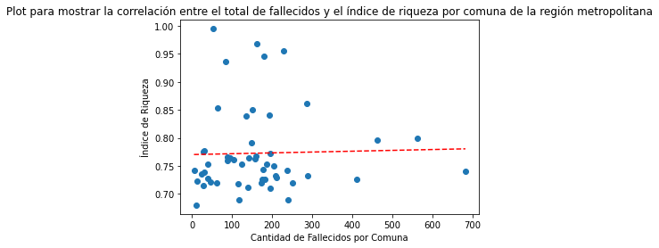

```python
x = Resumen['CANTIDAD_FALLECIDOS']
y = Resumen['HDI']

print(np.corrcoef(x, y))

plt.scatter(x, y, marker = 'o')
plt.title('Plot para mostrar la correlación entre el total de fallecidos y el índice de riqueza por comuna de la región metropolitana')
plt.xlabel('Cantidad de Fallecidos por Comuna')
plt.ylabel('Índice de Riqueza')
plt.plot(np.unique(x), np.poly1d(np.polyfit(x, y, 1))(np.unique(x)), 'r--',color='red')
plt.show()
```

#### Correlación Lineal entre las Dos Variables

```python
corr_test = pearsonr(x = Resumen['CANTIDAD_FALLECIDOS'], y = Resumen['HDI'])
print('El Coeficiente de Correlación de Pearson: ', corr_test[0])
print('Valor P: ', corr_test[1])
```

```
El Coeficiente de Correlación de Pearson:  0.027041176138371828
Valor P:  0.8490809159887946
```

#### Representación Gráfica N°2: HDI - Total de Vacunados

```
[[1.         0.47901378]
 [0.47901378 1.        ]]
```

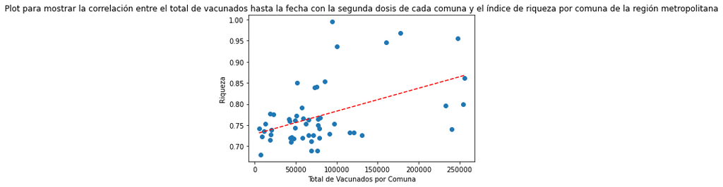

```python
x = Resumen['TOTAL_VACUNADOS']
y = Resumen['HDI']

print(np.corrcoef(x, y))

plt.scatter(x, y, marker = 'o')
plt.title('Plot para mostrar la correlación entre el total de vacunados hasta la fecha con la segunda dosis de cada comuna y el índice de riqueza por comuna de la región metropolitana')
plt.xlabel('Total de Vacunados por Comuna')
plt.ylabel('Riqueza')
plt.plot(np.unique(x), np.poly1d(np.polyfit(x, y, 1))(np.unique(x)), 'r--',color='red')
plt.show()
```

#### Correlación Lineal entre las dos Variables

```python
corr_test = pearsonr(x = Resumen['TOTAL_VACUNADOS'], y = Resumen['HDI'])
print('El Coeficiente de Correlación de Pearson: ', corr_test[0])
print('Valor P: ', corr_test[1])
```

```
El Coeficiente de Correlación de Pearson:  0.47901378313362286
Valor P:  0.00032753620239571853
```

#### Elaboración de la Regresión Lineal Mediante Ordinary Least Squares (OLS)

#### CANTIDAD DE FALLECIDOS => TOTAL DE VACUNADOS + HDI

```python
model = sm.ols(formula = 'CANTIDAD_FALLECIDOS ~TOTAL_VACUNADOS+HDI', data = Resumen).fit()
```

```python
print(model.params)
```

```
Intercept          631.790120
TOTAL_VACUNADOS      0.002070
HDI               -825.616455
dtype: float64
```

El intercepto correponde aproximadamente a 632 de fallecidos totales.

Por otro lado, la pendiente de la población considerada es muy baja con respecto a los fallecidos, lo cual por cada individuo vacunado con la segunda dosis, la cantidad de fallecidos totales aumenta en un 0.002070.

Finalmente, la pendiente del índice de desarrollo humano es negativa.

```python
print(model.summary())
```

```
                             OLS Regression Results
===============================================================================
Dep. Variable:     CANTIDAD_FALLECIDOS   R-squared:                       0.788
Model:                             OLS   Adj. R-squared:                  0.779
Method:                  Least Squares   F-statistic:                     91.08
Date:                 Fri, 09 Jul 2021   Prob (F-statistic):           3.12e-17
Time:                         18:40:12   Log-Likelihood:                -287.62
No. Observations:                   52   AIC:                             581.2
Df Residuals:                       49   BIC:                             587.1
Df Model:                            2
Covariance Type:             nonrobust
===================================================================================
                      coef    std err          t      P>|t|      [0.025      0.975]
-----------------------------------------------------------------------------------
Intercept         631.7901     99.574      6.345      0.000     431.689     831.892
TOTAL_VACUNADOS     0.0021      0.000     13.490      0.000       0.002       0.002
HDI              -825.6165    135.320     -6.101      0.000   -1097.553    -553.680
==============================================================================
Omnibus:                        1.449   Durbin-Watson:                   1.416
Prob(Omnibus):                  0.484   Jarque-Bera (JB):                0.688
Skew:                           0.090   Prob(JB):                        0.709
Kurtosis:                       3.534   Cond. No.                     1.99e+06
==============================================================================

Notes:
[1] Standard Errors assume that the covariance matrix of the errors is correctly specified.
[2] The condition number is large, 1.99e+06. This might indicate that there are
strong multicollinearity or other numerical problems.
```

#### Inferencia del Summary

- N° de Observaciones = 52, ya que corresponden a las 52 comunas de la Región Metropolitana de Chile.
- Coeficientes: como el valor p es menor a 0.05, la relación lineal es significativa.
- Valor R2: como es valor R2 es igual a 0.788, indica un buen ajuste del modelo definido. Es decir, la cantidad total de fallecidos se explica en un 78.8% de acuerdo a los parámetros del índice de desarrollo humano y el total de vacunados hasta la fecha.
- Valor R2 Ajustado: debe ser menor al valor R2, por lo tanto, se cumple, también indica la penalización de introducción de variables independientes